# Defining Symbolic Expressions

- Matlab has a symbolic math ability. Rather than making calculations on known numbers, we can make calculations on symbolic expressions.
- The key function in Matlab to create a symbolic representation of data is: `syms`

```matlab
syms x;
```

```matlab
syms a b c % Create multiple symbolic variables in one command
```

```matlab
A = sym('a',[1,20]) % Create the variables a1, ..., a20
```

```
A =

[ a1, a2, a3, a4, a5, a6, a7, a8, a9, a10, a11, a12, a13, a14, a15, a16, a17, a18, a19, a20]
```

```matlab
syms a b c x
f = a*x^2+b*x+c
```

```
f =

a*x^2 + b*x + c
```

```matlab
subs(f,x,5) % Assign a value to x
```

```
ans =

25*a + 5*b + c
```

```matlab
subs(f,[x a b c],[5 1 2 3]) % Assign a list of values to a, b, c and x
```

```
ans =

38
```

# Symbolic Algebra

- `expand(S):` Multiples out all the portions of the expression or equation

```matlab
syms x
expand((x-3)*(x+6))
```

```
ans =

x^2 + 3*x - 18
```

`factor(S)`: Factors the expression or equation

```matlab
syms x
factor(x^3-1)
```

```
ans =

[ x - 1, x^2 + x + 1]
```

- `collect(S)`: Collects like terms

```matlab
syms x
S = 2*(x+3)^2 + x^2 + 6*x + 9;
collect(S)
```

```
ans =

3*x^2 + 18*x + 27
```

- `simplify(S)`: Simplifies in accordance with MuPad's simplification rules

```matlab
syms x
simplify(exp(log(x)))
```

```
ans =

x
```

- `numden(S)`: Finds the numerator of an expression; this function is not valid for equations

```matlab
syms x
numden((x-5)/(x+5))
```

```
ans =

x - 5
```

- `[num,den] = numden(S)`: Finds bot the numerator and the denominator of an expression

```matlab
syms x
[num,den] = numden((x-5)/(x+5))
```

```
num =

x - 5


den =

x + 5
```

# Solving Expressions and Equations (`solve(S)`)

- `solve(S)`: Solves an expression with a single variable

```matlab
syms x
solve(x-5)
```

```
ans =

5
```

- `solve(S)`: Solves an equation with a single variable

```matlab
syms x
solve(x^2-2==5)
```

```
ans =

  7^(1/2)
 -7^(1/2)
```

- `solve(S)`: Solves an equation whose solutions are complex numbers

```matlab
syms x
solve(x^2==-5)
```

```
ans =

 -5^(1/2)*1i
  5^(1/2)*1i
```

- `solve(S)`: Solves an equation with more than one variable for x or the closest variable to x

```matlab
syms x y
solve(y==x^2+2)
```

```
ans =

  (y - 2)^(1/2)
 -(y - 2)^(1/2)
```

- `solve(S,y)`: Solves an equation with more than one variable for a specified variable

```matlab
syms x y
solve(y+6*x,x)
```

```
ans =

-y/6
```

- `solve(S1,S2,S3)`: Solves a system of equations and presents the solutions as a structure array

```matlab
syms x y z
one = 3*x+2*y-z==10;
two = -x+3*y+2*z==5;
three = x-y-z==-1;
solve(one,two,three)
```

```
ans =

  struct with fields:

    x: [1×1 sym]
    y: [1×1 sym]
    z: [1×1 sym]
```

- `[A,B,C] = solve(S1,S2,S3)`: Solves a system of equations and assigns the solutions to user-defined variable names; displays the results alphabetically

```matlab
syms x y z
one = 3*x+2*y-z==10;
two = -x+3*y+2*z==5;
three = x-y-z==-1;
[A,B,C] = solve(one,two,three)
```

```
A =

-2


B =

5


C =

-6
```

# Symbolic Plotting

- `ezplot(f)`: Plots a symbolic expression, equation, or function $f$. By default, `ezplot` plots a univariate expression or function over the range $[-2\pi,2\pi]$ or over a subinterval of this range. If $f$ is an equation or function of two variables, the default range for both variables, the default range for both variables is $[-2\pi,2\pi]$ or over a subinterval of this range.

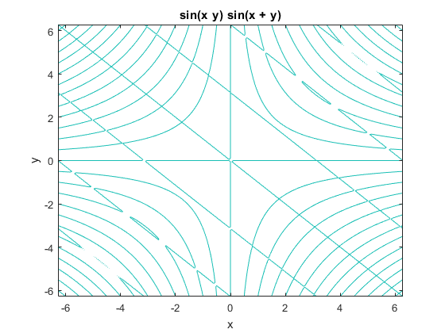

```matlab
syms x y
f(x,y)=sin(x+y)*sin(x*y);
ezplot(f)
```

- `ezplot(f,[min,max])`: plots $f$ over the specified range. If $f$ is a univariate expression or function, then $[min,max]$ specifies the range for that variable along the abscissa. If $f$ is an equation or function of two variables, then $[min,max]$ specifies the range for both variables along both the abscissa and the ordinate.

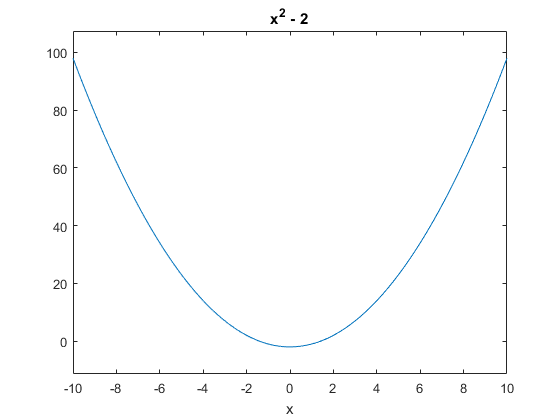

```matlab
syms x
y=x^2-2;
ezplot(y,[-10,10])
```

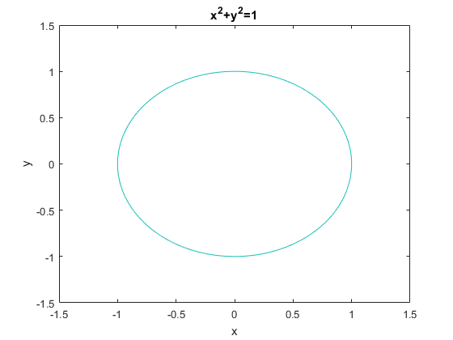

```matlab
ezplot('x^2+y^2=1',[-1.5,1.5])
```

- `ezplot(f,[xmin,xmax,ymin,ymax])`: Plots $f$ over the specified ranges along the abscissa and the ordinate.

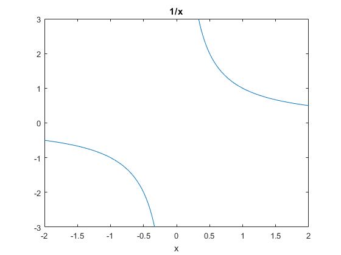

```matlab
syms x
a=1/x;
ezplot(a,[-2,2,-3,3])
```

# Symbolic Differentiation

- `diff(f)`: Returns the derivative of the expression $f$ with respect to the default independent variable.

```matlab
syms x z
y = x^3+z^2;
diff(y)
```

```
ans =

3*x^2
```

- `diff(f,'t')`: Returns the derivative of the expression $f$ with respect to the variable $t$.

```matlab
syms x z
y = x^3+z^2;
diff(y,'z')
```

```
ans =

2*z
```

- `diff(f,n)`: Returns the $n$th derivative of the expression $f$ with respect to the default independent variable.

```matlab
syms x z
y = x^3+z^2;
diff(y,2)
```

```
ans =

6*x
```

- `diff(f,'t',n)` : Returns the $n$th derivative of the expression $f$ with respect to the variable $t$.

```matlab
syms x z
y = x^3+z^2;
diff(y,'z',2)
```

```
ans =

2
```

# Symbolic Integration

- `int(f)`: Returns the integral of the expression $f$ with respect to the default independent variable.

```matlab
syms x z
y = x^3+z^2;
int(y)
```

```
ans =

x^4/4 + x*z^2
```

- `int(f,'t')`: Returns the integral of the expression $f$ with respect to the variable $t$.

```matlab
syms x z
y = x^3+z^2;
int(y,'z')
```

```
ans =

x^3*z + z^3/3
```

- `int(f,a,b)`: Returns the integral of the expression $f$ with respect to the default independent variable, between the numeric bounds $a$ and $b$.

```matlab
syms x z
y = x^3+z^2;
int(y,2,3)
```

```
ans =

z^2 + 65/4
```

- `int(f,'t',a,b)`: Returns the integral of the expression $f$ with respect to the variable $t$, between the numeric bounds $a$ and $b$.

```matlab
syms x z
y = x^3+z^2;
int(y,'z',2,3)
```

```
ans =

x^3 + 19/3
```

- `int(f,'t','a','b')`: Returns the integral of the expression $f$ with respect to the variable $t$, between the symbolic bounds $a$ and $b$.

```matlab
syms x z
y = x^3+z^2;
int(y,'z','a','b')
```

```
ans =

- a^3/3 - a*x^3 + b^3/3 + b*x^3
```

# Converting Symbolic Expressions and Equations

- `g = matlabFunction(f)`: Converts $f$ to a MATLAB function with the handle $g$. $f$ can be a symbolic expression, function, or a vector of symbolic expressions or functions.

```matlab
syms x y
s = sqrt(x^2+y^2);
g = matlabFunction(sin(s)/s)
```

```
g =

  function_handle with value:

    @(x,y)sin(sqrt(x.^2+y.^2)).*1.0./sqrt(x.^2+y.^2)
```

```matlab
syms x y
f(x,y) = sqrt(x^2+y^2);
g = matlabFunction(f)
```

```
g =

  function_handle with value:

    @(x,y)sqrt(x.^2+y.^2)
```